# Projet LSTAT2110 - Analyse des donnÃ©es

### *Analyse descriptive*

Pour commencer nous pouvons observer la répartition des pokémons en fonction de certaines variables. Premièrement la distribution des pokémons en fonctions de leur type, ainsi que le nombre de légendaires.

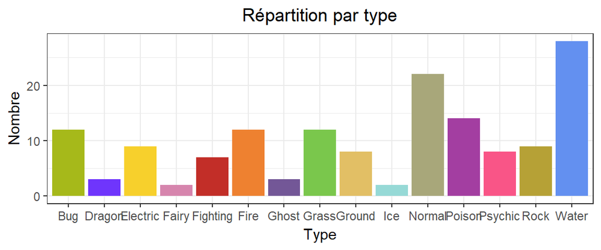

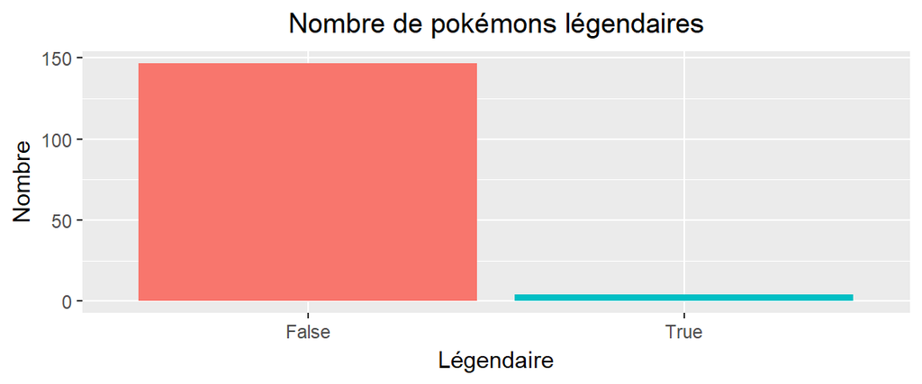

Nous pouvons observer sur le premier graphique que la répartition des spécimens par type est très inégale, certains type (water, normal,…) disposent d’un grand nombre d’individus contrairement à d’autres (dragon, fairy,…)  
Sur le deuxième graphique nous pouvons voir que les pokémons légendaires sont très peu nombreux (il en existe 4 dans cette génération).

Le prochain graphique va comparer les pokémons légendaires aux autres en fonction de la somme de leur statistiques (variable “total”).

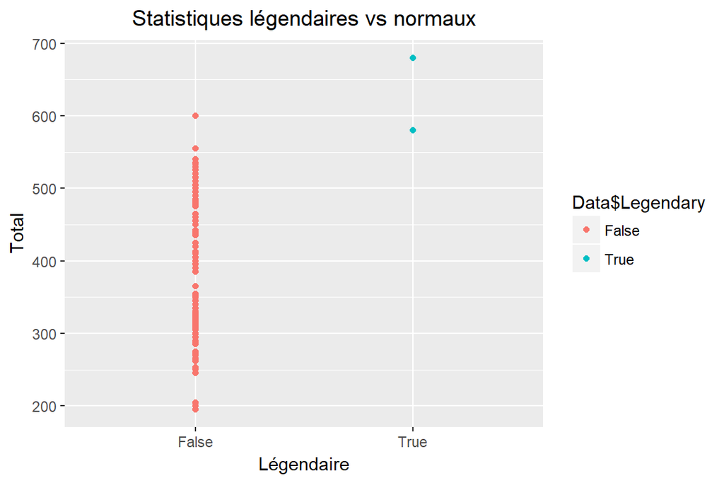

Il évident au vu du graphique que les pokémons légendaires disposent, en moyenne, de statistiques bien plus élevées. Nous pourrons donc certainement les distinguer (ainsi que de nouveaux individus) des autres grâce à l’analyse discriminante linéaire.

Nous allons maintenant nous intéresser à la distribution des différentes statistiques.

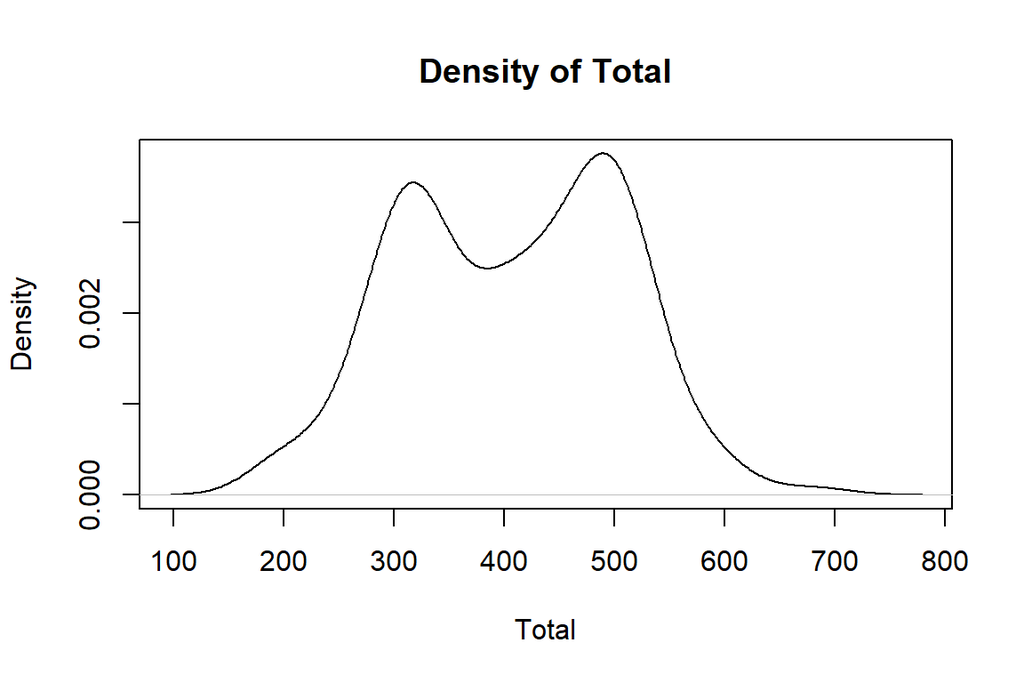

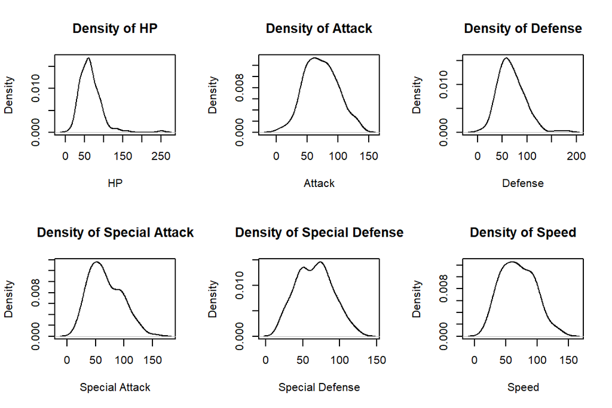

Nous pouvons voir que dans l’ensemble, les statistiques semblent suivre une loi gaussienne. Avec deux pics autours de 300 et 500 pour le total. (Sûrement expliqué par la différence de moyenne statistique entre un pokémon non-évolué et son évolution).

Regardons maintenant la matrice de corrélations des données.

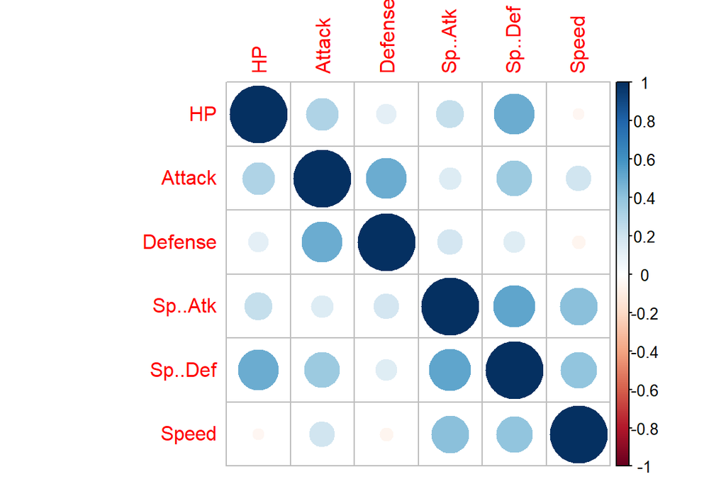

Sur ce graphique, nous pouvons voir que la majorité des variables sont positivement corrélées, ce qui peut vouloir dire que lorsqu’un individu gagne des statistiques, il en gagne de presque tous les types.  
Cependant il y a des exceptions, ainsi la vitesse est légèrement négativement corrélée avec les HP et la Défense. Ce résultat est assez intuitif et signifie globalement que plus un individu est rapide, moins il serait résistant.

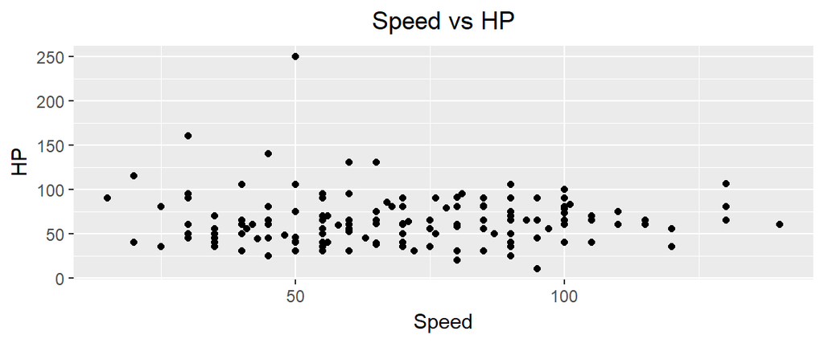

Sur le graphique nous voyons que cette corrélation est pratiquement négligeable.

Voici les autres relations intéressantes :

- L’attaque et la défense sont positivement corrélées.
- L’attaque spéciale et la défense spéciale sont également positivement corrélées

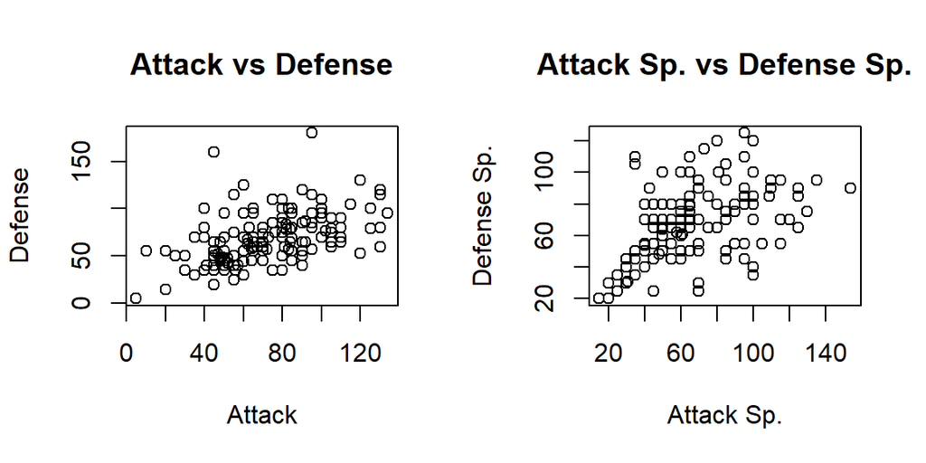

# Analyse en Composantes Principales

Nous allons maintenant passer à l’analyse en composantes principales de notre jeu de données.

[figure not shown]

|  | eigenvalue | percentage of variance | cumulative percentage of variance |
| --- | --- | --- | --- |
| comp 1 | 2.3810774 | 39.684623 | 39.68462 |
| comp 2 | 1.2983823 | 21.639704 | 61.32433 |
| comp 3 | 0.9841344 | 16.402240 | 77.72657 |
| comp 4 | 0.6752113 | 11.253521 | 88.98009 |
| comp 5 | 0.3418269 | 5.697115 | 94.67720 |
| comp 6 | 0.3193677 | 5.322796 | 100.00000 |

Ce tableau nous indique que les trois premières dimensions conservent environ 75% de la variance.

#### Corrélation des axes et des variables

|  | Dim.1 | Dim.2 | Dim.3 |
| --- | --- | --- | --- |
| HP | 0.5825333 | 0.2196265 | -0.7129478 |
| Attack | 0.6527662 | 0.4860255 | 0.2438546 |
| Defense | 0.4419946 | 0.6675834 | 0.4214754 |
| Sp..Atk | 0.6926334 | -0.3779357 | 0.0735561 |
| Sp..Def | 0.8307983 | -0.2026010 | -0.2322905 |
| Speed | 0.5003026 | -0.6199802 | 0.4235138 |

Sur le tableau ci-dessus, nous observons que la première dimension est assez bien caractérisée par toutes les variables (particulièrement l’attaque spéciale et la défense spéciale), seules la vitesse et la défense dont légèrement moins bien représentées.

Celles-ci sont en revanche les deux variables caractérisant le plus la deuxième dimension.  
Nous pouvons donc dire que le premier axe va représenter les caractéristiques générales d’un pokémon, tandis que le deuxième va plutôt nous indiquer la défense ou la rapidité d’un pokémon.

Comme la défense est positivement corrélée avec le deuxième axe (au contraire de la vitesse), on peut dire que plus un pokémon sera haut sur la deuxième dimension, plus il sera résistant (et à fortiori plus il sera lent).  
Mais ces résultats restent influencés dans une mesure non négligeable par les autres variables et il faut en tenir compte.

Pour vérifier que le premier axe représente les caractéristiques générales d’un pokémon, nous pouvons vérifier que les évolutions d’un pokémon vont être representées de manière presque horizontale. (En évoluant un pokémon gagnera de toutes les statistiques).

Voici les 9 premières lignes du jeu de données, représentant trois pokémons et leurs évolutions :

[figure not shown]

| X. | Name | Type.1 | Type.2 | Total | HP | Attack | Defense | Sp..Atk | Sp..Def | Speed |
| --- | --- | --- | --- | --- | --- | --- | --- | --- | --- | --- |
| 1 | Bulbasaur | Grass | Poison | 318 | 45 | 49 | 49 | 65 | 65 | 45 |
| 2 | Ivysaur | Grass | Poison | 405 | 60 | 62 | 63 | 80 | 80 | 60 |
| 3 | Venusaur | Grass | Poison | 525 | 80 | 82 | 83 | 100 | 100 | 80 |
| 4 | Charmander | Fire |  | 309 | 39 | 52 | 43 | 60 | 50 | 65 |
| 5 | Charmeleon | Fire |  | 405 | 58 | 64 | 58 | 80 | 65 | 80 |
| 6 | Charizard | Fire | Flying | 534 | 78 | 84 | 78 | 109 | 85 | 100 |
| 7 | Squirtle | Water |  | 314 | 44 | 48 | 65 | 50 | 64 | 43 |
| 8 | Wartortle | Water |  | 405 | 59 | 63 | 80 | 65 | 80 | 58 |
| 9 | Blastoise | Water |  | 530 | 79 | 83 | 100 | 85 | 105 | 78 |

Nous pouvons en effet constater dans le tableau que les statistiques évoluent toutes de manière relativement uniforme et que les évolutions des pokémons se déplacent bien de manière similaire sur la première dimension.

Nous avons aussi prédit précédemment que le deuxième axe indiquait la défense/vitesse d’un pokémon (respectivement vers le haut et vers le bas). Ces résultats se confirment aussi puisque l’individu bleu est en effet le plus résistant et le rouge est le plus rapide.

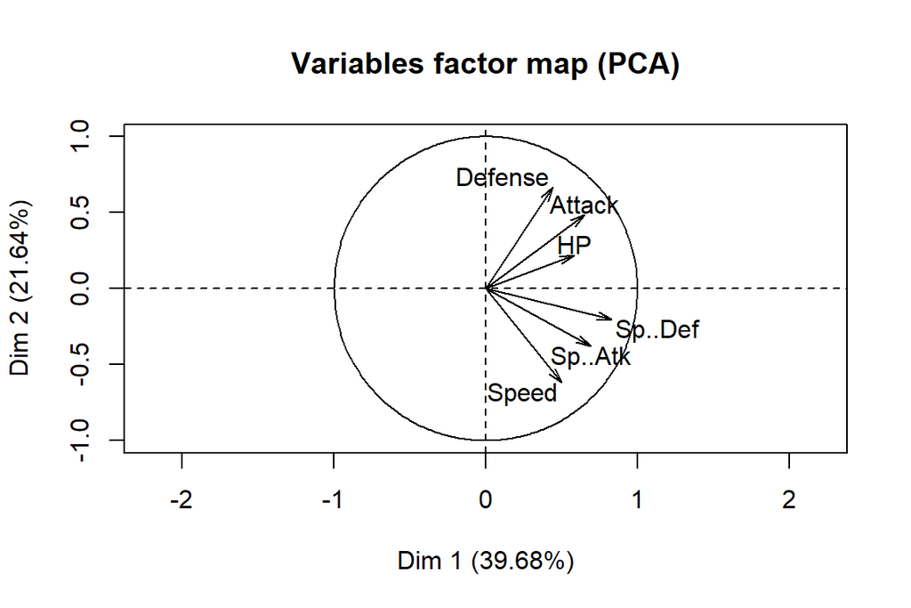

La sphère des corrélations quant à elle nous indique la même chose que la matrice des corrélation étudiée dans la section sur l’analyse descriptive.

# Clustering

Passons maintenant au clustering de notre jeu de données.

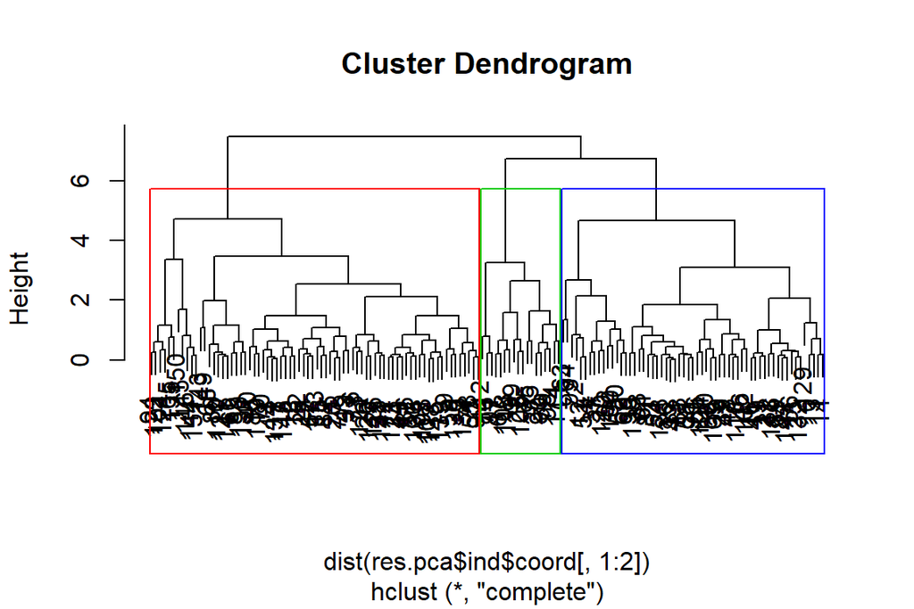

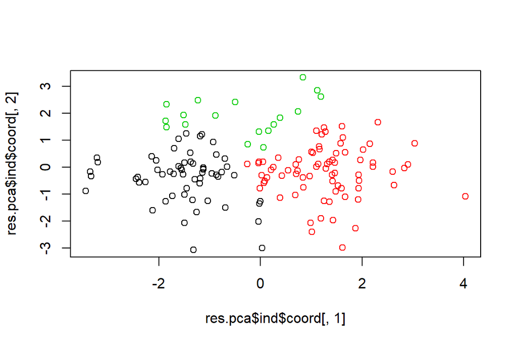

# Analyse des correspondances